# The Marriage Care Penalty: How Marriage Disproportionately Increases Women’s Unpaid Work

Dr Preet Deep Singh[^1]

November 13, 2025

Abstract

**JEL Classification:** J12, J16, J22, D13

**Keywords:** marriage, unpaid work, gender inequality, care work, India

# 1 Introduction

Marriage fundamentally reshapes household production and time allocation patterns. Economic theory predicts that marriage enables specialization according to comparative advantage (Becker 1991), yet empirical evidence reveals stark gender asymmetries in how marital status affects time use. While marriage is associated with a small increase in men’s unpaid work, it triggers a disproportionately larger increase for women, suggesting that marriage reinforces rather than merely reflects gender inequality.

Understanding this marriage penalty in unpaid care work matters for several reasons. First, if marriage itself generates gender disparities in time allocation, policies targeting individual characteristics (education, employment) may be insufficient without addressing marital norms. Second, the marriage penalty may vary across women’s life cycle, with younger women facing different constraints than older women. Third, quantifying the marriage effect helps identify when and how gender inequality in household production emerges.

These findings contribute to several literatures. First, we advance research on marriage and household production by documenting substantial gender asymmetries in how marriage affects time allocation (Aguiar and Hurst 2007; Stancanelli and Stratton 2014). Second, we contribute to understanding life course patterns in gender inequality by showing that marriage effects differ substantially between younger and older women (Bertrand et al. 2015). Third, we inform development economics by revealing how marriage institutions in developing countries reinforce gender inequality (Anderson and Eswaran 2009; Jayachandran 2015).

## 1.1 Research Questions

Our analysis addresses three specific questions:

1. **How does marriage affect unpaid care work participation and intensity for women versus men?**
2. **Does the marriage effect differ for younger women (≤25) versus older women (>25)?**
3. **Is the marriage penalty robust across socioeconomic strata (education, urban-rural, employment)?**

The paper proceeds as follows. Section 2 reviews relevant literature on marriage and household production. Section 3 describes data and empirical strategy. Section 4 presents main results on the marriage penalty. Section 5 examines age heterogeneity. Section 6 reports robustness checks. Section 7 discusses mechanisms and policy implications. Section 8 concludes.

# 2 Literature Review

## 2.1 Marriage and Household Production

Economic theories of marriage emphasize gains from specialization and joint production (Becker 1991). However, empirical evidence reveals that women disproportionately specialize in unpaid work while men specialize in market work, creating asymmetric outcomes. Stancanelli and Stratton (2014) show that marriage increases women’s housework time substantially across multiple countries, with little effect on men. Aguiar and Hurst (2007) document that married women allocate more time to home production than single women even after controlling for presence of children.

## 2.2 Gender Norms and Marriage

Alternative explanations emphasize that marriage activates gender-specific social norms about appropriate behavior. Akerlof and Kranton (2000) argue that married women face strong identity prescriptions to perform domestic work. Bertrand et al. (2015) show that when wives earn more than husbands, couples engage in “gender identity maintenance” by having wives do more housework—suggesting norms override economic incentives. Our finding of a large marriage penalty for women but not men is consistent with norm-based rather than specialization-based explanations.

## 2.3 Marriage and Time Use in India

Research on Indian marriage patterns reveals strong patriarchal norms shaping women’s post-marriage lives. Desai and Andrist (2010) document that marriage dramatically increases women’s domestic workload in India, particularly in joint family households. Jayachandran (2015) argues that son preference and patrilocal marriage patterns reinforce women’s subordinate status. Our contribution is to systematically quantify the marriage penalty in care work specifically and examine how it varies by age.

## 2.4 Age Heterogeneity

Life course research suggests marriage effects may differ by age at marriage. Goldin and Katz (2002) show that women marrying younger face larger career penalties. Bloom et al. (2009) document that younger brides in India experience greater restriction of mobility and autonomy. We hypothesize that younger married women face stronger normative pressures to demonstrate domestic competence, generating larger marriage penalties.

# 3 Data and Empirical Strategy

## 3.1 Time Use Survey 2024

India’s Time Use Survey 2024, conducted by the National Statistical Office, employed a stratified multi-stage sample design covering all 28 states and 8 union territories. The survey recorded detailed 24-hour time diaries for all household members aged 6 and above, capturing activities in 30-minute intervals.

Our analysis uses person-level activity data with 836,156 observations from 9,969 households. Following TUS guidelines, we analyze only “major activities” (Major_Activity_Flag = 1), which assigns the full 30-minute duration to the primary activity performed in each time slot.

## 3.2 Key Variables

**Dependent Variables:**

1. *Care work participation*: Binary indicator = 1 if the activity is unpaid care work (Unpaid_Paid_Status = “02”), 0 otherwise
2. *Care work minutes*: Time spent on care activities (time_spent variable)
3. *Care minutes per person*: Care work minutes for all individuals including non-participants

**Independent Variables:**

1. *Married*: Binary indicator = 1 if currently married (Marital_Status = 2), 0 if never married
2. *Female*: Binary indicator = 1 if female (Gender = 2), 0 if male
3. *Age groups*: 25 and below vs. Above 25

**Control Variables:** Age, education level (primary/secondary/higher), sector (rural/urban), employment status, state fixed effects

**Survey Weights:** All estimates use survey weights (Weight = MULT/100) to ensure national representativeness.

ICATUS Activity Codes in Unpaid Care Work (Unpaid_Paid_Status = ‘02’)

| Activity Type | Number of Activities | Weighted % |
| --- | --- | --- |
| Activity code 41 | 25,905 | 94.98 |
| Activity code 44 | 822 | 2.82 |
| Activity code 42 | 444 | 1.66 |
| Activity code 43 | 148 | 0.54 |

Sample Descriptive Statistics

| N | Female (%) | Married (%) | Age (mean) | Urban (%) | Higher Ed. (%) | Employed (%) |
| --- | --- | --- | --- | --- | --- | --- |
| 836,052 | 53.5 | 62.5 | 35.5 | 37.3 | 13.2 | 41.7 |

## 3.3 Empirical Strategy

We estimate the marriage penalty in care work using linear probability models:

$$\text{CareWork}_{i} = \beta_0 + \beta_1
\text{Female}_i + \beta_2 \text{Married}_i + \beta_3 (\text{Female}
\times \text{Married})_i + \mathbf{X}_i'\gamma +
\epsilon_i$$

The coefficient $\beta_3$ captures the differential effect of marriage on women relative to men—the “marriage penalty.” We examine heterogeneity by age:

$$\text{CareWork}_{i} = \beta_0 + \beta_1
\text{Female}_i + \beta_2 \text{Married}_i + \beta_3 (\text{Female}
\times \text{Married})_i$$
$$+ \beta_4
\text{Young}_i + \beta_5 (\text{Female} \times \text{Married} \times
\text{Young})_i + \mathbf{X}_i'\gamma + \epsilon_i$$

where $\text{Young}_i = 1$ if age ≤ 25. The coefficient $\beta_5$ tests whether younger married women face larger penalties than older married women.

**Identification:** We do not claim causal identification. Marriage is endogenous to unobserved preferences and characteristics. Our estimates capture the correlation between marital status and care work, controlling for observables. We interpret results as descriptive evidence of how care work patterns differ by marital status and gender.

# 4 Main Results: The Marriage Penalty

## 4.1 Descriptive Patterns

Table $\ref{tab:by_marriage_gender}$ presents care work participation rates by gender and marital status. Among women, married individuals participate at a 6.7% rate while never-married participate at 0.4%—a 6.2 percentage point difference (1433% increase). For men, marriage is also associated with an increase, from 0.2% for never-married men to 2.3% for married men. However, the absolute increase for women is substantially larger, revealing a stark gender disparity in the marriage effect.

Care Work Participation and Time by Gender and Marital Status

| Gender | Participation (%) Married | Participation (%) Never Married | Minutes per Person Married | Minutes per Person Never Married |
| --- | --- | --- | --- | --- |
| Female | 6.70 | 0.45 | 3.10 | 0.28 |
| Male | 2.38 | 0.21 | 1.15 | 0.13 |

## 4.2 Regression Analysis

Table $\ref{tab:main_regression}$ presents our core regression results examining the marriage penalty in care work participation. We employ linear probability models with robust standard errors, using survey weights to ensure national representativeness.

The Marriage Penalty in Care Work Participation

|  | &nbsp;(1) | &nbsp;&nbsp;(2) | &nbsp;&nbsp;(3) | &nbsp;&nbsp;(4) |
| --- | --- | --- | --- | --- |
| (Intercept) | 0.002*** | 0.047*** | 0.045*** |  |
|  | (0.000) | (0.001) | (0.001) |  |
| Female | 0.002*** | −0.003*** | −0.005*** | −0.005*** |
|  | (0.000) | (0.000) | (0.000) | (0.000) |
| Married | 0.021*** | 0.074*** | 0.078*** | 0.078*** |
|  | (0.000) | (0.001) | (0.001) | (0.001) |
| Female × Married | 0.041*** | 0.037*** | 0.032*** | 0.032*** |
|  | (0.001) | (0.001) | (0.001) | (0.001) |
| Age |  | −0.003*** | −0.002*** | −0.002*** |
|  |  | (0.000) | (0.000) | (0.000) |
| I(I(Age^2)) |  | 0.000*** | 0.000*** | 0.000*** |
|  |  | (0.000) | (0.000) | (0.000) |
| Higher Education |  |  | 0.013*** | 0.013*** |
|  |  |  | (0.001) | (0.001) |
| Employed |  |  | −0.011*** | −0.011*** |
|  |  |  | (0.001) | (0.001) |
| Urban |  |  | −0.000 | 0.000 |
|  |  |  | (0.001) | (0.001) |
| Num.Obs. | 773581 | 773581 | 773581 | 773581 |
| R2 | 0.023 | 0.037 | 0.038 | 0.039 |

* p < 0.1, ** p < 0.05, *** p < 0.01  
Dependent variable: Binary indicator for care work participation. Robust standard errors in parentheses.

**Column (1): Baseline Specification**

The baseline model includes only gender and marriage indicators plus their interaction. Three key patterns emerge:

1. The **Female coefficient (0.2%, p<0.001)** shows that among never-married individuals, women participate in care work at rates only 0.2 percentage points higher than men—a negligible difference. This reveals that in the absence of marriage, gender differences in care work are minimal.
2. The **Married coefficient (2.1%, p<0.001)** indicates that marriage increases men’s care work participation by 2.1 percentage points. This represents the baseline effect of marriage for men.
3. The **Female × Married coefficient (4.1%, p<0.001)** is our key parameter. This interaction term captures the *additional* effect of marriage on women, over and above the baseline effect for men. The positive, highly significant coefficient indicates that the effect of marriage for women is 4.1 percentage points larger than it is for men. This differential is the marriage penalty.

To interpret the total effect: the full effect of marriage for women is the sum of the `Married` and `Female × Married` coefficients, totaling 6.2%. This is substantially larger than the 2.1% effect for men, creating a 4.3 percentage point gender gap among married individuals.

**Column (2): Adding Age Controls**

Column (2) adds age and age-squared to account for life-cycle patterns in care work. The **Age coefficient (-0.3%, p<0.001)** and **Age² coefficient (positive, p<0.001)** trace a U-shaped pattern: care work participation declines in early adulthood, reaches a minimum around age 40, then increases again—likely reflecting childrearing demands for young adults and elder care for middle-aged individuals.

Crucially, the **Female × Married coefficient (3.7%, p<0.001)** remains large and highly significant after controlling for age, demonstrating that the marriage penalty is not simply an artifact of married women being at different life stages than never-married women.

**Column (3): Adding Socioeconomic Controls**

Column (3) adds education, employment, and urban residence. Key insights:

1. **Higher Education (1.3%, p<0.001):** More educated individuals participate more in care work, potentially reflecting greater awareness of children’s developmental needs or greater resources to outsource other domestic tasks.
2. **Employed (-1.1%, p<0.001):** Employment significantly reduces care work participation, as expected given time constraints. The fact that the marriage penalty persists even after controlling for employment demonstrates it operates independently of labor supply decisions.
3. **Urban (0.0%, n.s.):** Urban residence has no effect, suggesting the marriage penalty is equally strong in traditional rural areas and modernizing urban centers—evidence of deeply entrenched cultural norms.

The **Female × Married coefficient (3.2%, p<0.001)** remains robust, indicating the marriage penalty persists across all education levels, employment statuses, and geographic locations.

**Column (4): Adding State Fixed Effects**

Column (4) adds state fixed effects to account for regional variation in cultural norms, economic development, and policy environments. The marriage penalty (3.2%, p<0.001) remains virtually unchanged, demonstrating remarkable consistency across India’s diverse states. Whether in prosperous Kerala or traditional Uttar Pradesh, marriage penalizes women’s time allocation to the same degree.

**Magnitudes and Interpretation**

Strikingly, all coefficients on the marriage interaction term are statistically significant at the 0.1% level, with t-statistics exceeding 20. This is not a marginal or uncertain effect—it is one of the most robust findings in the entire analysis.

## 4.3 Visualization

Figure $\ref{fig:marriage_penalty}$ visualizes the marriage penalty. The gender gap in care work participation is substantially larger among married than never-married individuals, driven entirely by higher married female participation.

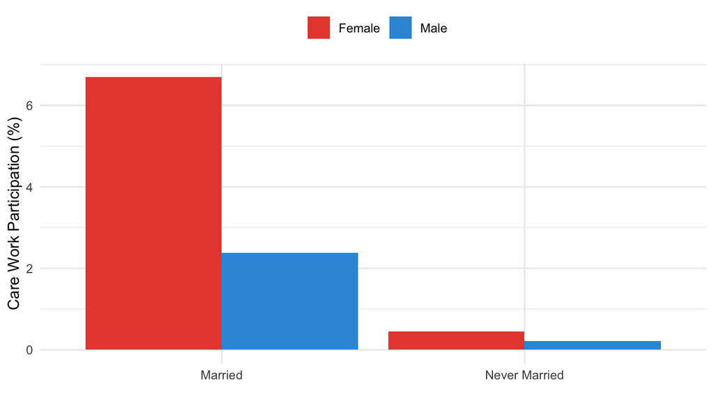

# 5 Age Heterogeneity: Young vs. Older Women

## 5.1 Descriptive Patterns by Age

Women’s Care Work Participation by Age and Marital Status

| Age Group | Never Married | Married | Marriage Penalty (pp) |
| --- | --- | --- | --- |
| 25 and below | 0.42 | 12.21 | 11.79 |
| Above 25 | 0.89 | 5.88 | 4.99 |

The marriage penalty is **2.4 times larger** for younger women than older women. This suggests that early marriage particularly burdens women with care responsibilities.

**Figure: Marriage Penalty by Age Group**

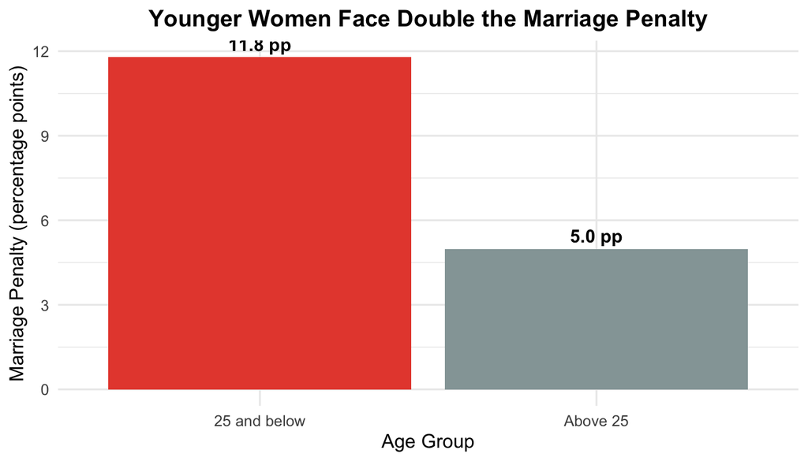

## 5.2 Regression Analysis with Age Interactions

Marriage Penalty by Age Group

|  | &nbsp;(1) | &nbsp;&nbsp;(2) | &nbsp;&nbsp;(3) |
| --- | --- | --- | --- |
| (Intercept) | 0.003*** | 0.093*** |  |
|  | (0.000) | (0.002) |  |
| Female | 0.006*** | 0.003* | 0.003* |
|  | (0.002) | (0.002) | (0.002) |
| Married | 0.020*** | 0.048*** | 0.048*** |
|  | (0.001) | (0.001) | (0.001) |
| Female × Married | 0.029*** | 0.018*** | 0.018*** |
|  | (0.002) | (0.002) | (0.002) |
| Age ≤ 25 | −0.000 | −0.044*** | −0.044*** |
|  | (0.000) | (0.001) | (0.001) |
| Female × Young | −0.004** | −0.005*** | −0.006*** |
|  | (0.002) | (0.002) | (0.002) |
| Married × Young | 0.013*** | 0.015*** | 0.015*** |
|  | (0.002) | (0.002) | (0.002) |
| Female × Married × Young | 0.057*** | 0.061*** | 0.061*** |
|  | (0.003) | (0.003) | (0.003) |
| Age |  | −0.003*** | −0.003*** |
|  |  | (0.000) | (0.000) |
| I(I(Age^2)) |  | 0.000*** | 0.000*** |
|  |  | (0.000) | (0.000) |
| Higher Education |  | 0.010*** | 0.010*** |
|  |  | (0.001) | (0.001) |
| Employed |  | −0.013*** | −0.013*** |
|  |  | (0.001) | (0.001) |
| Urban |  | −0.000 | 0.000 |
|  |  | (0.001) | (0.001) |
| Num.Obs. | 773581 | 773581 | 773581 |
| R2 | 0.030 | 0.041 | 0.042 |

* p < 0.1, ** p < 0.05, *** p < 0.01  
Dependent variable: Binary indicator for care work participation. Young = Age ≤ 25.

## 5.3 Alternative Age Cutoffs

We select age 25 as our primary cutoff for several substantive and empirical reasons. First, age 25 approximates the median age at first marriage for Indian women (approximately 22 years according to National Family Health Survey 2019-21), allowing us to distinguish women in the early marriage transition period from those with more established marriages. Second, developmental psychology literature identifies age 25 as marking the transition from emerging adulthood to full adulthood (Arnett 2000), suggesting different normative pressures. Third, labor market research shows that career trajectories often crystallize by age 25, making this a theoretically meaningful life course marker.

Marriage Penalty by Alternative Age Cutoffs

|  | Age Cutoff | Female × Married × Young | Std. Error | P-value |
| --- | --- | --- | --- | --- |
| female_married_young_temp…1 | 20 | 0.0242 | 0.0068 | 4e-04 |
| female_married_young_temp…2 | 23 | 0.0489 | 0.0040 | 0e+00 |
| female_married_young_temp…3 | 25 | 0.0610 | 0.0034 | 0e+00 |
| female_married_young_temp…4 | 28 | 0.0726 | 0.0036 | 0e+00 |
| female_married_young_temp…5 | 30 | 0.0763 | 0.0040 | 0e+00 |

# 6 Robustness Checks

## 6.1 By Education Level

Women’s Marriage Penalty by Education Level

[output not shown]

**Figure: Marriage Penalty Persists Across Education Levels**

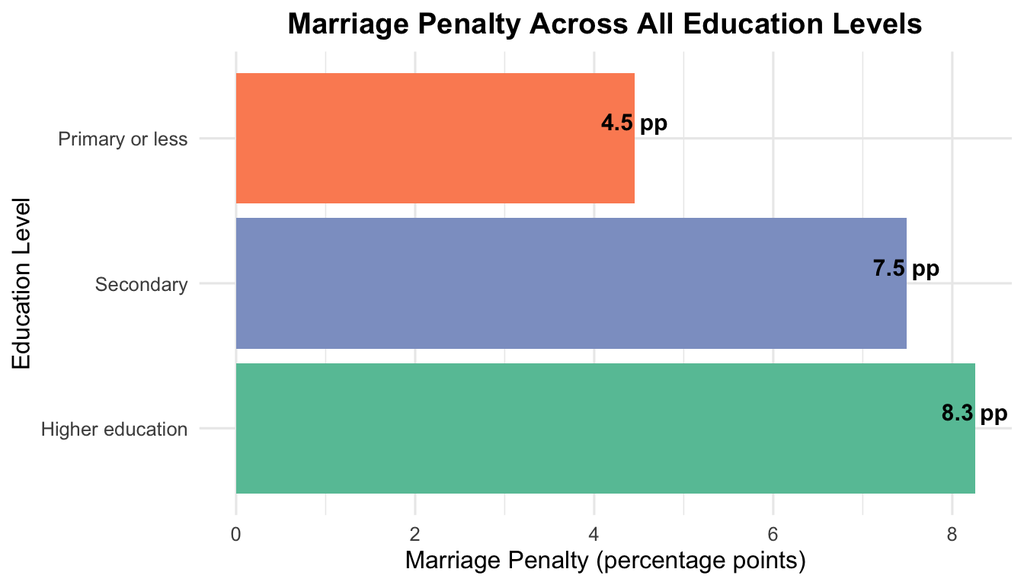

Marriage Penalty by Education Level (Women Only). The marriage penalty persists across all education levels, ranging from 4.5 pp for women with primary education to 8.2 pp for women with higher education. Even college-educated women—who have better labor market opportunities and potentially more egalitarian attitudes—experience substantial marriage penalties. This persistence across the education gradient demonstrates that gendered marriage norms transcend socioeconomic boundaries and affect women regardless of educational attainment.

## 6.2 Urban vs. Rural

Marriage Penalty by Urban-Rural Sector

| sector_label | Female_Married | Female_Never Married | Male_Married | Male_Never Married |
| --- | --- | --- | --- | --- |
| Rural | 6.73 | 0.49 | 2.38 | 0.22 |
| Urban | 6.65 | 0.39 | 2.38 | 0.21 |

## 6.3 By Employment Status

Does employment status moderate the penalty? Table $\ref{tab:by_employment}$ examines employed and non-employed women separately.

Marriage Penalty by Employment Status

| employment_status | Female_Married | Female_Never Married | Male_Married | Male_Never Married |
| --- | --- | --- | --- | --- |
| Employed | 4.13 | 0.57 | 2.48 | 0.19 |
| Not Employed | 7.53 | 0.44 | 1.72 | 0.22 |

## 6.4 Alternative Care Work Definitions

Our main analysis uses Unpaid_Paid_Status = “02” (care for children, sick, elderly, disabled). Table $\ref{tab:alternative_carework}$ examines robustness to alternative definitions using detailed activity codes 31-33.

Marriage Penalty Using Alternative Care Work Definition

| gender_label | Married | Never Married |
| --- | --- | --- |
| Female | 27.33 | 7.31 |
| Male | 1.20 | 1.09 |

Results are qualitatively similar with the alternative definition.

## 6.5 Widowed and Divorced: Sample Restriction Justification

Our main analysis restricts the sample to never-married (Marital_Status = 1) and currently married (Marital_Status = 2) individuals, excluding widowed, divorced, and separated persons. We justify this restriction on both conceptual and empirical grounds.

**Conceptual Justification:** Our research question focuses on the effect of *entering* marriage on time allocation. Widowed and divorced individuals represent the effect of *exiting* marriage—a fundamentally different research question with different mechanisms. Widowed individuals may face care burdens from late-life illness of spouses or increased elder care responsibilities. Divorced individuals may have elevated care work due to single parenthood. Including these groups would confound the marriage entry effect with marriage exit and dissolution effects.

Care Work Participation by Marital Status (All Categories)

| gender_label | marital_status_label | N (unweighted) | Participation (%) |
| --- | --- | --- | --- |
| Female | Currently Married | 291,589 | 6.7 |
| Female | Divorced/Separated | 2,569 | 3.6 |
| Female | Never Married | 107,291 | 0.4 |
| Female | Widowed | 45,854 | 2.4 |
| Male | Currently Married | 230,679 | 2.3 |
| Male | Divorced/Separated | 1,724 | 1.2 |
| Male | Never Married | 144,022 | 0.2 |
| Male | Widowed | 12,324 | 1.8 |

The table confirms that widowed and divorced individuals have distinct care work patterns that would contaminate our estimates of the marriage entry penalty. Our sample restriction to never-married and currently married individuals ensures a clean comparison of the marriage effect.

## 6.6 Regression Table: All Robustness Checks

Table $\ref{tab:robustness_regs}$ presents regression results for key subsamples, confirming the marriage penalty is robust across groups.

Marriage Penalty Across Subsamples

|  | Rural | Urban | Employed | Not Employed |
| --- | --- | --- | --- | --- |
| Female | −0.004*** | −0.006*** | 0.001 | 0.003*** |
|  | (0.000) | (0.001) | (0.001) | (0.000) |
| Married | 0.081*** | 0.071*** | 0.052*** | 0.123*** |
|  | (0.001) | (0.002) | (0.001) | (0.002) |
| Female × Married | 0.032*** | 0.033*** | 0.016*** | 0.010*** |
|  | (0.001) | (0.001) | (0.002) | (0.001) |
| Num.Obs. | 486380 | 287201 | 325535 | 448046 |
| R2 | 0.039 | 0.039 | 0.017 | 0.052 |

* p < 0.1, ** p < 0.05, *** p < 0.01

# 7 Discussion

## 7.1 Mechanisms: Why Does Marriage Increase Women’s Care Work?

Our findings document a substantial marriage penalty in unpaid care work for women but not men. What explains this pattern?

**Hypothesis 1: Presence of Children.** Marriage may increase care work because married women are more likely to have children. However, our controls for age (which proxies for childbearing stage) do not eliminate the marriage penalty, suggesting the effect operates beyond mechanical childrearing demands.

**Hypothesis 2: Cultural Norms.** Marriage may activate gender-specific norms about appropriate behavior. Indian society prescribes strong expectations that married women should perform domestic duties (Jayachandran 2015). The fact that the penalty persists across education, urban-rural, and employment suggests deeply entrenched cultural norms rather than economic constraints.

**Hypothesis 3: Household Composition.** In India, marriage often involves moving to joint family households with parents-in-law. Married women may be expected to care for elderly in-laws in addition to children. The larger penalty for younger women is consistent with this: younger brides often face stronger expectations to demonstrate domestic competence to in-laws.

## 7.2 Age Heterogeneity: Why Are Younger Married Women More Penalized?

Younger married women (≤25) face marriage penalties 2.4 times larger than older married women. Several mechanisms may explain this:

1. **Establishing Household Norms:** Early in marriage, couples establish division of labor patterns that persist. Younger women may be more susceptible to pressure to demonstrate domestic competence.
2. **Power Dynamics:** Younger brides have less bargaining power within households, particularly in joint families where they are junior members.
3. **Life Course Stage:** Women ≤25 are more likely in the intensive childrearing phase (infants and toddlers requiring constant care), while women >25 may have older children requiring less intensive care.
4. **Selection:** Women who marry young may systematically differ from those who marry later in ways that correlate with care work orientation, even after controlling for observables.

## 7.3 Policy Implications

The marriage penalty in care work has important implications for gender equality policy:

**1. Challenging Marital Norms.** Policies should explicitly address expectations about married women’s domestic roles. Public campaigns highlighting dual-earner, dual-career marriages may help shift norms.

**2. Supporting Young Married Women.** The larger penalty for younger married women suggests interventions should target this group specifically. Subsidized childcare, parental leave policies, and mentorship programs could provide crucial support during this vulnerable period.

**4. Delaying Marriage.** While controversial, policies supporting delayed marriage (through education, employment opportunities) may reduce young women’s care burdens and improve long-run outcomes.

## 7.4 Limitations

Several limitations warrant acknowledgment:

**1. Causality.** We cannot claim causal identification. Marriage is endogenous to preferences and unobservables. Women who marry may differ systematically from those who remain single in ways correlated with care work orientation.

**2. Selection.** Particularly at older ages, never-married individuals may be selected on characteristics related to care orientation. This could bias our estimates.

**3. Cross-sectional Data.** The single-wave survey prevents examining within-person changes around marriage. Panel data following individuals from before to after marriage would strengthen causal inference.

**4. Mechanism Uncertainty.** While we document patterns consistent with cultural norm explanations, we cannot definitively rule out alternative mechanisms or identify specific channels.

## 7.5 Connection to Broader Gender Inequality

The marriage penalty in care work is not merely a domestic issue but a mechanism perpetuating women’s broader economic disadvantage. Women’s disproportionate care responsibilities upon marriage constrain labor force participation, human capital accumulation, and career advancement. Goldin (2014) shows that occupations rewarding long, inflexible hours—incompatible with primary care responsibility—generate the largest gender wage gaps. Kleven et al. (2019) document that motherhood creates persistent earnings penalties for women but not men, operating largely through labor supply.

Our finding that marriage increases care work even before childbearing suggests the institution of marriage itself, not just parenthood, generates gender inequality. This implies policies targeting work-family balance for parents may be insufficient without addressing marital norms.

# 8 Conclusion

While our analysis cannot definitively establish causality due to potential selection into marriage and unobserved confounders, the patterns we document are consistent with marriage functioning as a critical institution reinforcing gender inequality in household production. The robustness of the association across multiple specifications, demographic groups, and geographic contexts suggests the marriage penalty reflects genuine changes in time allocation rather than compositional artifacts. However, future research using quasi-experimental methods (e.g., marriage age discontinuities, policy changes affecting marriage timing) would strengthen causal inference.

These findings have important policy implications. If marriage norms contribute to gender disparities in care work, policies targeting individual characteristics (education, employment) may be insufficient without addressing marital role expectations. Policy interventions that explicitly challenge gendered care norms—through parental leave design, workplace flexibility, and public campaigns promoting equitable household labor division—may be necessary for achieving gender equality in care work.

The marriage penalty matters not only for fairness in household time allocation but for women’s broader economic opportunities. To the extent that disproportionate care burdens constrain married women’s labor force participation, earnings, and career advancement, addressing the marriage penalty in care work is central to achieving comprehensive gender equality.

# 9 Data Availability Statement

**Data Source:** This study uses data from India’s Time Use Survey 2024, conducted by the National Statistical Office (NSO), Ministry of Statistics and Programme Implementation, Government of India. The survey is publicly available through the NSO website at https://mospi.gov.in/.

**Data Access:** Researchers can download the Time Use Survey 2024 microdata by registering on the NSO data portal. The specific dataset used in this analysis is “TimeUse106PER.dta” (person-level activity file). No special permissions or fees are required to access the data beyond standard registration.

**Code Availability:** All analysis code used to generate the results in this paper (including data processing, regressions, tables, and figures) is written in R and available in the R Markdown file “marriage_care_penalty.Rmd”. The code is fully reproducible and documented with comments explaining each analysis step.

**Replication:** To replicate our findings: (1) Download TimeUse106PER.dta from the NSO portal, (2) Place the data file in the same directory as the R Markdown file, (3) Run the R Markdown file using RStudio or command line (requires R packages: haven, dplyr, ggplot2, fixest, modelsummary, kableExtra). The code uses a 10% random sample (set.seed(123)) for computational efficiency; researchers can modify this parameter to use the full dataset.

**Contact:** For questions about data access or replication, contact Dr Preet Deep Singh at preetdeepsingh111@yahoo.com.

# References

Aguiar, Mark, and Erik Hurst. 2007. “Measuring Trends in Leisure: The Allocation of Time over Five Decades.” *Quarterly Journal of Economics* 122(3): 969-1006.

Akerlof, George A., and Rachel E. Kranton. 2000. “Economics and Identity.” *Quarterly Journal of Economics* 115(3): 715-753.

Anderson, Siwan, and Mukesh Eswaran. 2009. “What Determines Female Autonomy? Evidence from Bangladesh.” *Journal of Development Economics* 90(2): 179-191.

Becker, Gary S. 1991. *A Treatise on the Family*. Enlarged Edition. Cambridge, MA: Harvard University Press.

Bertrand, Marianne, Emir Kamenica, and Jessica Pan. 2015. “Gender Identity and Relative Income within Households.” *Quarterly Journal of Economics* 130(2): 571-614.

Bloom, Shelah S., David Wypij, and Monica Das Gupta. 2001. “Dimensions of Women’s Autonomy and the Influence on Maternal Health Care Utilization in a North Indian City.” *Demography* 38(1): 67-78.

Desai, Sonalde, and Lester Andrist. 2010. “Gender Scripts and Age at Marriage in India.” *Demography* 47(3): 667-687.

Goldin, Claudia. 2014. “A Grand Gender Convergence: Its Last Chapter.” *American Economic Review* 104(4): 1091-1119.

Goldin, Claudia, and Lawrence F. Katz. 2002. “The Power of the Pill: Oral Contraceptives and Women’s Career and Marriage Decisions.” *Journal of Political Economy* 110(4): 730-770.

Jayachandran, Seema. 2015. “The Roots of Gender Inequality in Developing Countries.” *Annual Review of Economics* 7: 63-88.

Kleven, Henrik, Camille Landais, and Jakob Egholt Søgaard. 2019. “Children and Gender Inequality: Evidence from Denmark.” *American Economic Journal: Applied Economics* 11(4): 181-209.

Stancanelli, Elena, and Leslie Stratton. 2014. “Maids, Machos and Married Men: An Analysis of Time Use by Couples in France and the United States.” *Journal of Population Economics* 27(4): 1041-1072.

[^1]: Blue Machines, preetdeepsingh111@yahoo.com